# sample_project

Я работаю в добывающей компании «ГлавРосГосНефть». Руководству компании, с моей помощью нужно решить, где бурить новую скважину.

Шаги для выбора локации:

- В избранном регионе ищут месторождения, для каждого определяют значения признаков;
- Строят модель и оценивают объём запасов;
- Выбирают месторождения с самым высокими оценками значений. Количество месторождений зависит от бюджета компании и стоимости разработки одной скважины;
- Прибыль равна суммарной прибыли отобранных месторождений.

Описание данных:

Данные геологоразведки трёх регионов находятся в файлах:

/datasets/geo_data_0.csv /datasets/geo_data_1.csv /datasets/geo_data_2.csv Для упрощения:

- будем называть регионы месторождениями нефти
- порядковый номер месторождений сохраним так же как и названия файлов трех регионов: 0, 1, 2.

Признаки:

id — уникальный идентификатор скважины; f0, f1, f2 — три признака точек (неважно, что они означают, но сами признаки значимы); product — объём запасов в скважине (тыс. баррелей).

1 Шаг. Загрузка и подготовка данных

Устанавливаем новые и обновляем уже имеющиеся библиотеки в целях их совместной корректной работы с визуализацией и при взаимодействии с моделями. Не отображаем процесс инсталляции для экономии места.

Импортируем библиотеки

```python
import numpy as np
import pandas as pd
import seaborn as sn
import os
import phik
import warnings
from phik.report import plot_correlation_matrix
from phik import report
from matplotlib import pyplot as plt
from sklearn.linear_model import LinearRegression
from sklearn.preprocessing import StandardScaler
from sklearn.model_selection import train_test_split
from sklearn.metrics import mean_squared_error
```

Считаем файлы данных и сохраним их в датафреймы. Поиск пути к файлам работает как для "Юпитера", как и для локального положения.

```python
pth1j = '/datasets/geo_data_0.csv'
pth1 = 'geo_data_0.csv'
pth2j = '/datasets/geo_data_1.csv'
pth2 = 'geo_data_1.csv'
pth3j = '/datasets/geo_data_2.csv'
pth3 = 'geo_data_2.csv'

if os.path.exists(pth1j):
    data0 = pd.read_csv(pth1j)
elif os.path.exists(pth1):
    data0 = pd.read_csv(pth1)
else:
    print('Something go wrong with path №1')

if os.path.exists(pth2j):
    data1 = pd.read_csv(pth2j)
elif os.path.exists(pth2):
    data1 = pd.read_csv(pth2)
else:
    print('Something go wrong with path №2')

if os.path.exists(pth3j):
    data2 = pd.read_csv(pth3j)
elif os.path.exists(pth3):
    data2 = pd.read_csv(pth3)
else:
    print('Something go wrong with path №3')
```

Для удобства установим внутренний индекс как колонку id для каждого датафрейма.

```python
data0 = data0.set_index('id')
data1 = data1.set_index('id')
data2 = data2.set_index('id')
```

Проверим, что данные в датафреймах соответствуют описанию:

```python
print('')
print('\033[1m','Данные геологоразведки первого региона')
data0.head()
```

```
 Данные геологоразведки первого региона
```

| id | f0 | f1 | f2 | product |
| --- | --- | --- | --- | --- |
| txEyH | 0.705745 | -0.497823 | 1.221170 | 105.280062 |
| 2acmU | 1.334711 | -0.340164 | 4.365080 | 73.037750 |
| 409Wp | 1.022732 | 0.151990 | 1.419926 | 85.265647 |
| iJLyR | -0.032172 | 0.139033 | 2.978566 | 168.620776 |
| Xdl7t | 1.988431 | 0.155413 | 4.751769 | 154.036647 |

```python
data0.info()
```

```
<class 'pandas.core.frame.DataFrame'>
Index: 100000 entries, txEyH to 1CWhH
Data columns (total 4 columns):
 #   Column   Non-Null Count   Dtype
---  ------   --------------   -----
 0   f0       100000 non-null  float64
 1   f1       100000 non-null  float64
 2   f2       100000 non-null  float64
 3   product  100000 non-null  float64
dtypes: float64(4)
memory usage: 3.8+ MB
```

```python
data0.duplicated().sum()
np.int64(0)
print('')
print('\033[1m','Данные геологоразведки второго региона')
data1.head()
```

```
 Данные геологоразведки второго региона
```

| id | f0 | f1 | f2 | product |
| --- | --- | --- | --- | --- |
| kBEdx | -15.001348 | -8.276000 | -0.005876 | 3.179103 |
| 62mP7 | 14.272088 | -3.475083 | 0.999183 | 26.953261 |
| vyE1P | 6.263187 | -5.948386 | 5.001160 | 134.766305 |
| KcrkZ | -13.081196 | -11.506057 | 4.999415 | 137.945408 |
| AHL4O | 12.702195 | -8.147433 | 5.004363 | 134.766305 |

```python
data1.duplicated().sum()
np.int64(0)
print('')
print('\033[1m','Данные геологоразведки третьего региона')
```

```
 Данные геологоразведки третьего региона
```

```python
data2.head()
```

| id | f0 | f1 | f2 | product |
| --- | --- | --- | --- | --- |
| fwXo0 | -1.146987 | 0.963328 | -0.828965 | 27.758673 |
| WJtFt | 0.262778 | 0.269839 | -2.530187 | 56.069697 |
| ovLUW | 0.194587 | 0.289035 | -5.586433 | 62.871910 |
| q6cA6 | 2.236060 | -0.553760 | 0.930038 | 114.572842 |
| WPMUX | -0.515993 | 1.716266 | 5.899011 | 149.600746 |

```python
data2.info()
```

```
<class 'pandas.core.frame.DataFrame'>
Index: 100000 entries, fwXo0 to V9kWn
Data columns (total 4 columns):
 #   Column   Non-Null Count   Dtype
---  ------   --------------   -----
 0   f0       100000 non-null  float64
 1   f1       100000 non-null  float64
 2   f2       100000 non-null  float64
 3   product  100000 non-null  float64
dtypes: float64(4)
memory usage: 3.8+ MB
```

```python
data2.duplicated().sum()
np.int64(0)
```

```
0
```

Напишем функцию для попарного вывода гистограммы и боксплота каждого из признаков в наших датафреймах:

```python
def plotandbox(data, feature, hist_color='darkslategray'):
    fig, axs = plt.subplots(nrows = 1 , ncols = 2, figsize = (12, 4))
    sn.histplot(data = data, x = feature, ax=axs[0], bins = 50, kde=True, color=hist_color, edgecolor='black')
    axs[0].set_xlabel(feature)
    axs[0].set_ylabel('частота')
    sn.boxplot(data = data, x = feature, ax=axs[1], color='azure')
    axs[1].set_xlabel(feature)
    fig.suptitle(f'Анализ распределения {feature}')
    plt.show()
```

Графический анализ данных

```python
data0.describe()
```

|  | f0 | f1 | f2 | product |
| --- | --- | --- | --- | --- |
| count | 100000.000000 | 100000.000000 | 100000.000000 | 100000.000000 |
| mean | 0.500419 | 0.250143 | 2.502647 | 92.500000 |
| std | 0.871832 | 0.504433 | 3.248248 | 44.288691 |
| min | -1.408605 | -0.848218 | -12.088328 | 0.000000 |
| 25% | -0.072580 | -0.200881 | 0.287748 | 56.497507 |
| 50% | 0.502360 | 0.250252 | 2.515969 | 91.849972 |
| 75% | 1.073581 | 0.700646 | 4.715088 | 128.564089 |
| max | 2.362331 | 1.343769 | 16.003790 | 185.364347 |

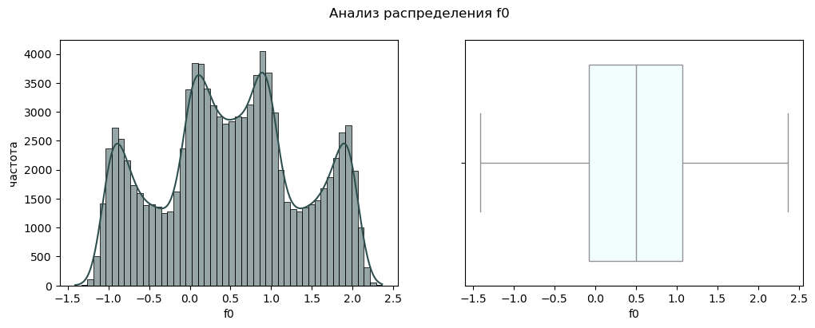

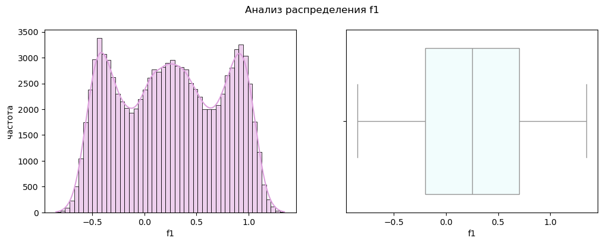

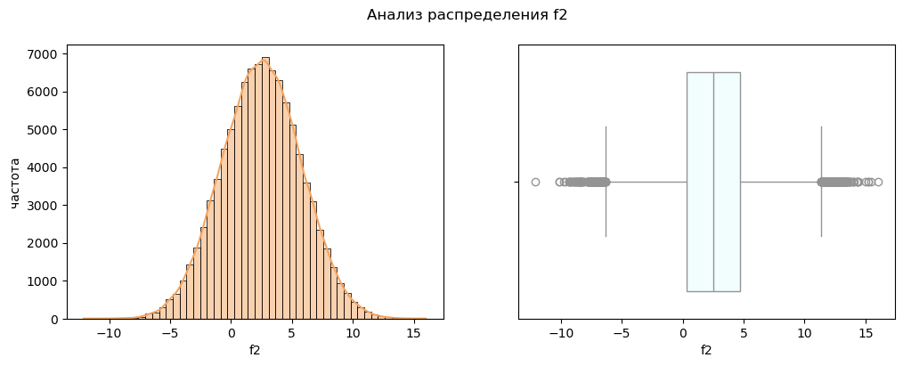

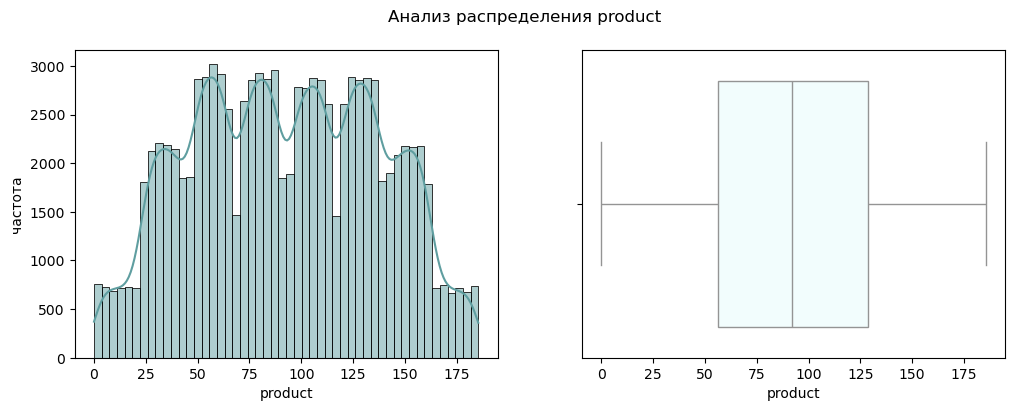

```python
plotandbox(data0, 'f0')
plotandbox(data0, 'f1', 'plum')
plotandbox(data0, 'f2', 'sandybrown')
plotandbox(data0, 'product', 'cadetblue')
```

Вывод:

- у признака f2 замечены "усы"
- думаю что усы можно не обрезать, что бы сохранить количественное единообразие данных

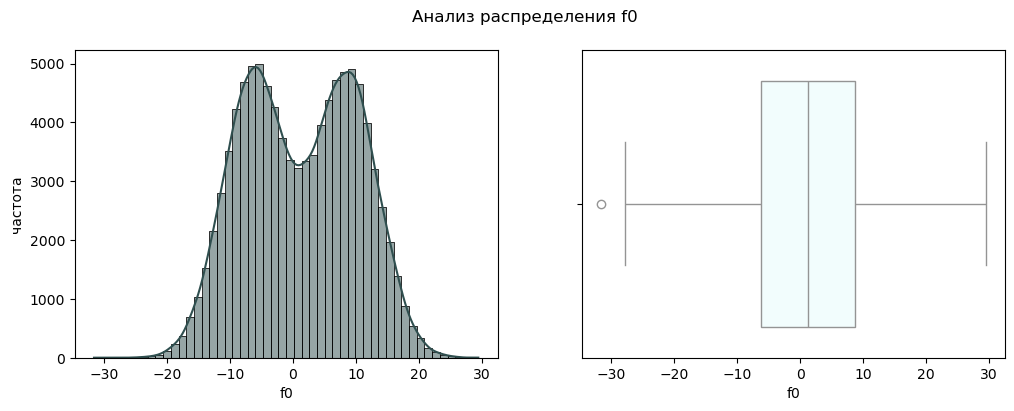

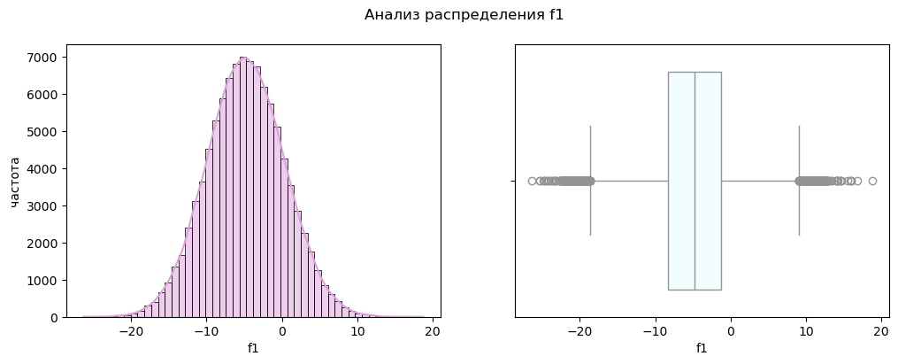

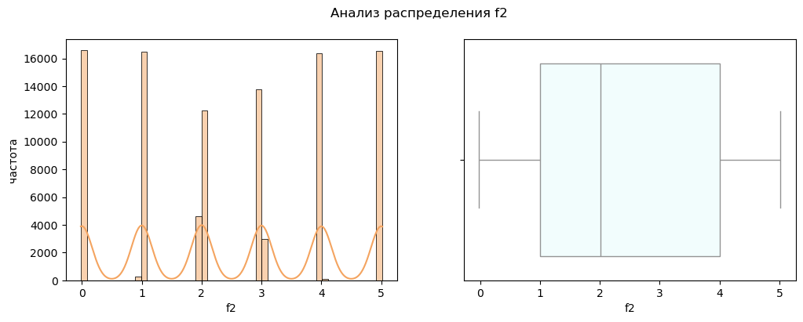

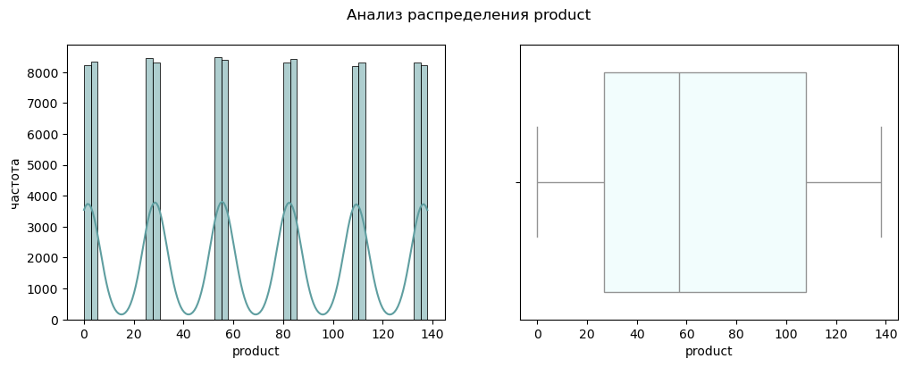

```python
plotandbox(data1, 'f0')
plotandbox(data1, 'f1', 'plum')
plotandbox(data1, 'f2', 'sandybrown')
plotandbox(data1, 'product', 'cadetblue')
```

Вывод:

- у признака f1 замечены "усы"
- странный, периодический характер данных гистограмм f2 и product - это не выбросы
- замечено сильное внешнее сходство гистограмм признака f2 и целевого признака product
- все значения признаков f2 и product выстроились по шести кластерам, встречаемость их выше почти в 3 раза

```python
data2.describe()
```

|  | f0 | f1 | f2 | product |
| --- | --- | --- | --- | --- |
| count | 100000.000000 | 100000.000000 | 100000.000000 | 100000.000000 |
| mean | 0.002023 | -0.002081 | 2.495128 | 95.000000 |
| std | 1.732045 | 1.730417 | 3.473445 | 44.749921 |
| min | -8.760004 | -7.084020 | -11.970335 | 0.000000 |
| 25% | -1.162288 | -1.174820 | 0.130359 | 59.450441 |
| 50% | 0.009424 | -0.009482 | 2.484236 | 94.925613 |
| 75% | 1.158535 | 1.163678 | 4.858794 | 130.595027 |
| max | 7.238262 | 7.844801 | 16.739402 | 190.029838 |

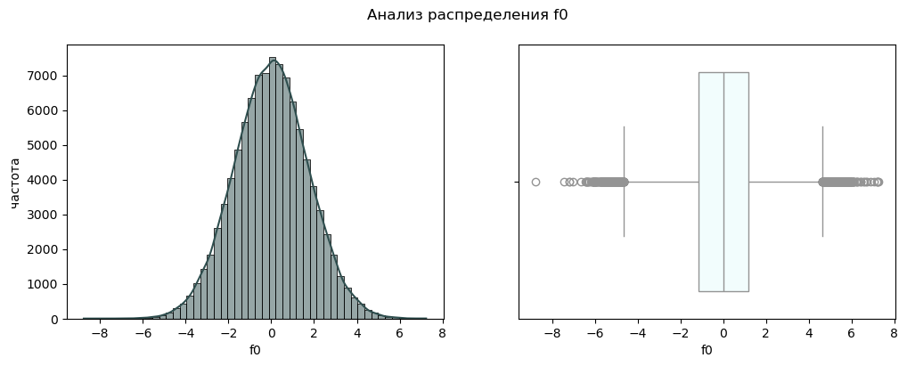

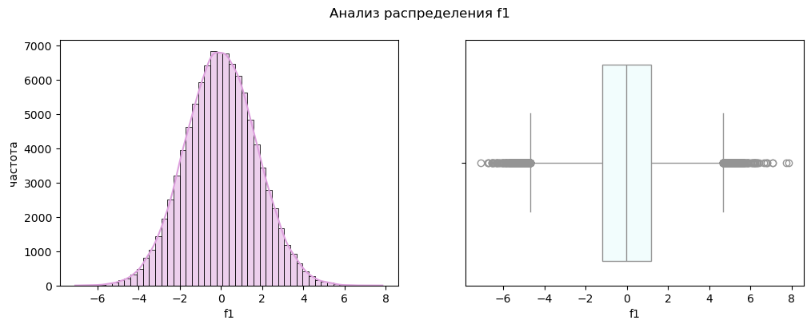

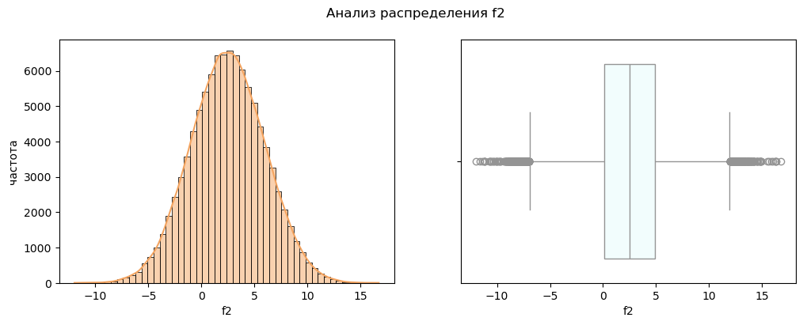

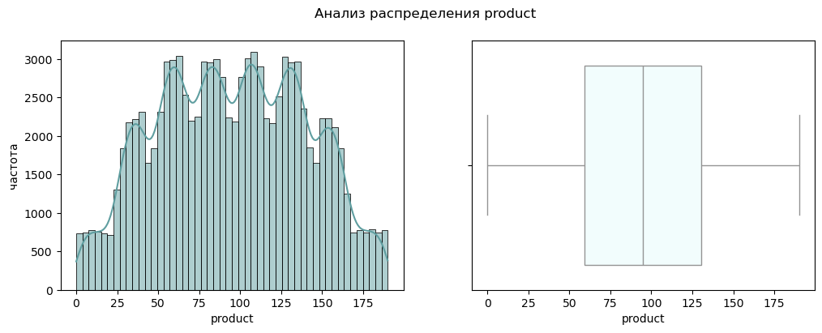

```python
plotandbox(data2, 'f0')
plotandbox(data2, 'f1', 'plum')
plotandbox(data2, 'f2', 'sandybrown')
plotandbox(data2, 'product', 'cadetblue')
```

Вывод:

- в data2 у всех признаков кроме целевого замечены "усы"
- думаю что усы можно не обрезать, что бы сохранить количественное единообразие данных

Корреляционный анализ данных

Напишем функцию для вывода корреляций наших датафреймов:

```python
def corephima(dataframe_name, interval_cols=['f0', 'f1', 'f2', 'product'], title=r"корреляция", fontsize_factor=1.5, figsize=(6, 4)):
    phik_overview = dataframe_name.phik_matrix(interval_cols)
    plot_correlation_matrix(
        phik_overview.values,
        x_labels=phik_overview.columns,
        y_labels=phik_overview.index,
        title=title,
        fontsize_factor=fontsize_factor,
        figsize=figsize
    )
```

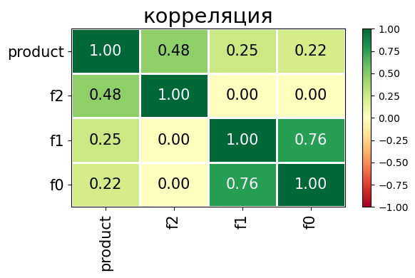

```python
corephima(data0)
```

Выводы:

- Сильная прямая корреляция у f1 и f0.
- Негативных моментов потенциально влияющих на модель - не замечено.

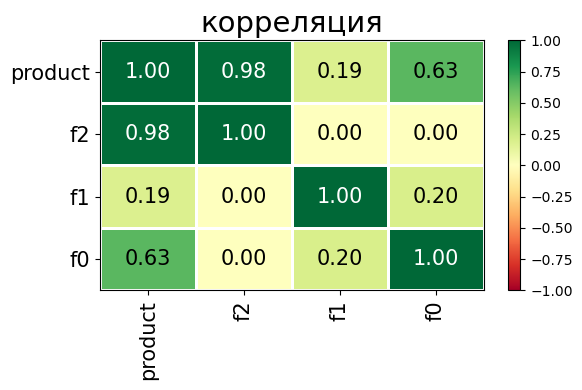

```python
corephima(data1)
```

Самым значимым признаком в data1 является f2:

- вероятнее всего, он будет играть основную роль в предсказаниях
- модель может стать менее робастной, если признак содержит шум или выбросы
- считаем что мультиколлинеарности нет, так как нет других сильных связей с f0 и f1

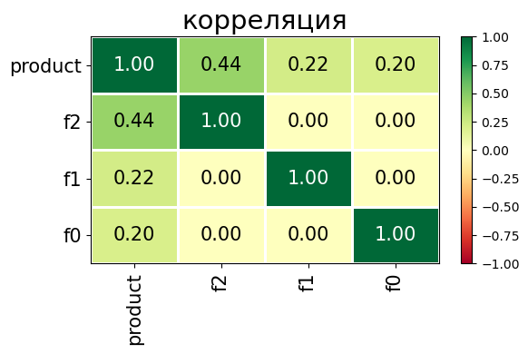

```python
corephima(data2)
```

- Негативных моментов потенциально влияющих на модель исходя из анализа корреляций - не замечено.

Выводы по ШАГУ-1:

- импортированы необходимые библиотеки
- колонку id установили в качестве внутреннего индекса, для удобства
- ознакомились с датасетами: тип данных - везде вещественный, тип переменной - везде количественный
- датасеты проверены на пропуски и дубликаты, которых обнаружено не было.

2 Шаг. Обучение и проверка модели

```python
warnings.filterwarnings("ignore")

RANDOM_STATE = 42
X0 = data0.drop('product', axis = 1)
y0 = data0['product']
X0_train, X0_valid, y0_train, y0_valid = train_test_split(X0, y0, test_size=0.25, random_state=RANDOM_STATE)
scaler0 = StandardScaler()
X0_train_scaler = scaler0.fit_transform(X0_train)
X0_valid_scaler = scaler0.transform(X0_valid)
model0 = LinearRegression()
model0.fit(X0_train_scaler, y0_train)
predict0 = model0.predict(X0_valid_scaler)
mean0 = predict0.mean()
rmse0 = mean_squared_error(y0_valid, predict0, squared=False)
print(f'Средний запас предсказанного сырья: {mean0}, значение метрики RMSE: {rmse0}')
```

```
Средний запас предсказанного сырья: 92.39879990657768, значение метрики RMSE: 37.75660035026169
```

data1:

```python
X1 = data1.drop('product', axis = 1)
y1 = data1['product']
X1_train, X1_valid, y1_train, y1_valid = train_test_split(
        X1,
        y1,
        test_size=0.25,
        random_state=RANDOM_STATE
)
scaler1 = StandardScaler()
X1_train_scaler = scaler1.fit_transform(X1_train)
X1_valid_scaler = scaler1.transform(X1_valid)
model1 = LinearRegression()
model1.fit(X1_train_scaler, y1_train)
predict1 = model1.predict(X1_valid_scaler)
mean1 = predict1.mean()
rmse1 = mean_squared_error(y1_valid, predict1, squared=False)
print(f'Средний запас предсказанного сырья: {mean1}, значение метрики RMSE: {rmse1}')
```

```
Средний запас предсказанного сырья: 68.7128780391376, значение метрики RMSE: 0.8902801001028837
```

data2:

```python
X2 = data2.drop('product', axis = 1)
y2 = data2['product']
X2_train, X2_valid, y2_train, y2_valid = train_test_split(
        X2,
        y2,
        test_size=0.25,
        random_state=RANDOM_STATE
)
scaler2 = StandardScaler()
X2_train_scaler = scaler2.fit_transform(X2_train)
X2_valid_scaler = scaler2.transform(X2_valid)
model2 = LinearRegression()
model2.fit(X2_train_scaler, y2_train)
predict2 = model2.predict(X2_valid_scaler)
mean2 = predict2.mean()
rmse2 = mean_squared_error(y2_valid, predict2, squared=False)
print(f'Средний запас предсказанного сырья: {mean2}, значение метрики RMSE: {rmse2}')
```

```
Средний запас предсказанного сырья: 94.77102387765939, значение метрики RMSE: 40.14587231134218
```

Выводы:

- наибольший средний запас предсказанного сырья у второго месторождения (94.8)
- на втором месте с незначительной разницей идёт нулевое месторождение (92.4)
- наименьшие запасы у первого месторождения (68.7)
- модель первого месторождения работает точнее всего (значение метрики RMSE там меньше единицы, а чем ближе значение метрики к нулю, тем точнее модель. В тоже время у других месторождений значение метрики в районе 40)

3 Шаг. Подготовка к расчёту прибыли

Для разработки выбирают 200 лучших скважин:

```python
n = 200
```

Бюджет на разработку скважин 10 млрд. рублей:

```python
budget = 10 * 10**9
```

Доход с единицы продукта:

```python
revenue = 450000
```

Сколько выделяется денег на одну скважину:

```python
budget_one = budget/n
```

Достаточный объем сырья, для безубыточной разработки новой скважины:

```python
volume = budget_one / revenue
```

Вывод:

- в каждой скважине объем сырья должен быть не меньше, чем 111.111, что бы не возникло убытков
- если объем будет меньше, то затраты на бурение не окупятся

```python
delta0 = mean0 - volume
delta1 = mean1 - volume
delta2 = mean2 - volume
display(delta0,delta1,delta2)
np.float64(-18.712311204533435)
np.float64(-42.39823307197351)
np.float64(-16.340087233451726)
```

```
-18.712311204533435
```

```
-42.39823307197351
```

```
-16.340087233451726
```

[output not shown]

Вывод:

- средние запасы в каждом регионе меньше, необходимого для безубыточности объема
- исходя из графиков, найти 200 месторождений с объемом продукта выше чем точка безубыточности будет не сложно.

Нужно найти 200 лучших месторождений с как можно большими залежами нефти, что бы максимизировать прибыль.

4 Шаг. Расчёт рисков и прибыли для каждого региона

```python
def profit(data, y_true, y_predict):
    data['predict'] = y_predict
    data['true'] = y_true
    data = data.sort_values(by = 'predict', ascending = False)
    data = data.head(200)
    profite = data['true'].sum()*450000 - budget
    return profite
```

```python
state = np.random.RandomState(12345)
```

Применим технику Bootstrap с 1000 выборок, чтобы найти распределение прибыли:

```python
prib0 = []
for i in range(1000):
    subsample = X0_valid.sample(n=500, replace = True, random_state=state)
    prib0.append(profit(subsample, y0_valid, pd.DataFrame(predict0, index = X0_valid.index)))

prib1 = []
for i in range(1000):
    subsample = X1_valid.sample(n=500, replace = True, random_state=state)
    prib1.append(profit(subsample, y1_valid, pd.DataFrame(predict1, index = X1_valid.index)))

prib2 = []
for i in range(1000):
    subsample = X2_valid.sample(n=500, replace = True, random_state=state)
    prib2.append(profit(subsample, y2_valid, pd.DataFrame(predict2, index = X2_valid.index)))
```

Средняя прибыль нулевого региона:

```python
pd.Series(prib0).mean()
np.float64(406278783.42441905)
```

```
406278783.42441905
```

Найдём 95% доверительный интервал для нулевого региона:

```python
lower = pd.Series(prib0).quantile(0.025)
upper = pd.Series(prib0).quantile(0.975)
print(f'95%-доверительный интервал для нулевого региона от {lower} до {upper}')
```

```
95%-доверительный интервал для нулевого региона от -117742136.49486831 до 911737050.7514055
```

Вычислим риск убытков в нулевом регионе:

```python
len([i for i in prib0 if i<0])/len(prib0)*100 # Процент отрицательных значений в нулевом регионе
```

```
6.7
```

Средняя прибыль первого региона:

```python
pd.Series(prib1).mean()
np.float64(441504277.5922549)
```

```
441504277.5922549
```

Найдём 95% доверительный интервал для первого региона:

```python
lower = pd.Series(prib1).quantile(0.025)
upper = pd.Series(prib1).quantile(0.975)
print(f'95%-доверительный интервал для первого региона от {lower} до {upper}')
```

```
95%-доверительный интервал для первого региона от 35728489.280851334 до 828006639.0043902
```

Вычислим риск убытков в первом регионе:

```python
len([i for i in prib1 if i<0])/len(prib1)*100 # Процент отрицательных значений в первом регионе
1.6
```

```
1.6
```

Средняя прибыль второго региона:

```python
pd.Series(prib2).mean()
np.float64(385213195.91415244)
```

```
385213195.91415244
```

Найдём 95% доверительный интервал для второго региона:

```python
lower = pd.Series(prib2).quantile(0.025)
upper = pd.Series(prib2).quantile(0.975)
print(f'95%-доверительный интервал для второго региона от {lower} до {upper}')
```

```
95%-доверительный интервал для второго региона от -164785166.1090443 до 888206234.1976783
```

Вычислим риск убытков во втором регионе:

```python
len([i for i in prib2 if i<0])/len(prib2)*100 # Процент отрицательных значений во втором регионе
7.8
```

```
7.8
```

Итоговый вывод:

Для разработки месторождений предлагается регион №1 (второй по счёту).

Обоснование:

- Это единственный регион с вероятностью убытков меньше 2.5
- В доверительном интервале нет отрицательных значений, значит 95% значений - прибыль, а не убытки.
- Среднее значение прибыли в этом регионе - 441504277.5922549

Поэтому именно этот регион лучше всего подойдёт для разработки